# An Introduction to Statistical Learning (2013)

Solutions to Applied Exercises

by Brian Hassett

# Chapter 3 Linear Regression

This notebook is a rough outline of solutions to the applied exercises in Chapter 3 of **An Introduction to Statistical Learning** (James et al. (2013)[^1]).

## Setup

```r
library(ISLR)
library(tidyverse)
library(patchwork)
library(MASS)
library(GGally)
theme_set(theme_bw())

# Given a filename, return the filepath. Default folder is the `data` folder in the current working directory.
get_path <- function(filename) {
  str_c(getwd(), "data", filename, sep = "/")
}

# Colors:
ISLR_blue <- "#176FC0"
ISLR_brown <- "#94340E"
```

## Exercise 8

### (a)

```r
mod1 <- lm(mpg ~ horsepower, data = Auto)
summary(mod1)
```

```
Call:
lm(formula = mpg ~ horsepower, data = Auto)

Residuals:
     Min       1Q   Median       3Q      Max
-13.5710  -3.2592  -0.3435   2.7630  16.9240

Coefficients:
             Estimate Std. Error t value Pr(>|t|)
(Intercept) 39.935861   0.717499   55.66   <2e-16 ***
horsepower  -0.157845   0.006446  -24.49   <2e-16 ***
---
Signif. codes:  0 ‘***’ 0.001 ‘**’ 0.01 ‘*’ 0.05 ‘.’ 0.1 ‘ ’ 1

Residual standard error: 4.906 on 390 degrees of freedom
Multiple R-squared:  0.6059,    Adjusted R-squared:  0.6049
F-statistic: 599.7 on 1 and 390 DF,  p-value: < 2.2e-16
```

### (i)

Yes. The F-statistic is much greater than one, and the p-value is close to zero, so we can reject the null hypothesis that the regression coefficients are zero.

### (ii)

The R-squared value is 0.61, so approximately 61% of the variance in `mpg` is explained by `horsepower`.

### (iii)

The regression coefficient for `horsepower` is negative, so the relationship between `horsepower` and `mpg` is negative.

### (iv)

Calculate the predicted `mpg` associated with a `horsepower` of 98:

```r
predict(mod1, data.frame(horsepower = 98))
```

```
       1
24.46708
```

Calculate the associated 95% confidence intervals:

```r
predict(mod1, data.frame(horsepower = 98), interval="confidence")
```

```
       fit      lwr      upr
1 24.46708 23.97308 24.96108
```

Calculate the associated 95% prediction intervals:

```r
predict(mod1, data.frame(horsepower = 98), interval="prediction")
```

```
       fit     lwr      upr
1 24.46708 14.8094 34.12476
```

### (b)

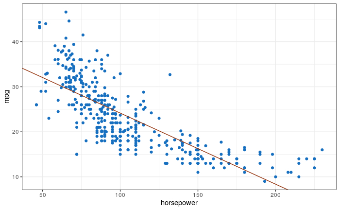

```r
coefs <- coefficients(mod1)
ggplot(Auto, aes(horsepower, mpg)) +
  geom_point(color = ISLR_blue) +
  geom_abline(intercept = coefs[1], slope = coefs[2],
              color = ISLR_brown)
```

### (c)

*Parts of this section are adapted from: https://data.library.virginia.edu/diagnostic-plots/ which has a nice explanation of residuals plots.)*

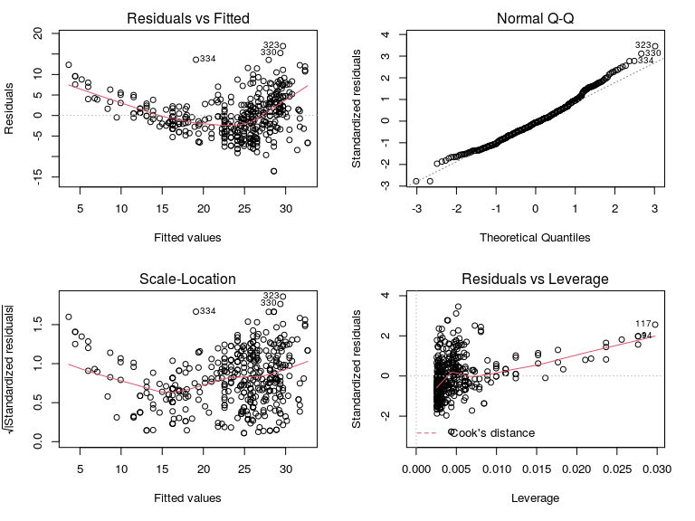

```r
#plot_lm_diagnostics(mod1) # There are issues with these plots, use base R instead
par(mfrow = c(2, 2))
plot(mod1)
```

#### Residuals vs Fitted Value

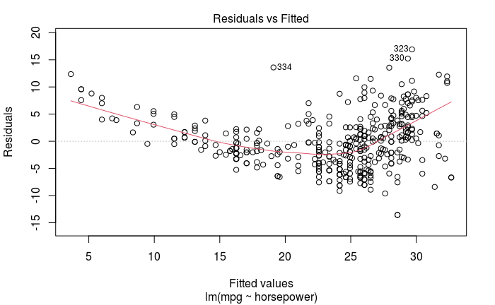

```r
#lindia::gg_resfitted(mod1)
plot(mod1, which = 1)
```

The above plot can be inspected for trends in the residuals. There is a strong indication of non-linearity in the data. Additionally there appears to be more spread in the residuals on the right-hand side of the plot. That is to say there appears to be more variance in the residuals for observations with higher fitted values.

The below residual plot is for a linear regression of `mpg` on `horsepower` and `horsepower^2`. There appears to be little pattern in the residuals, suggesting that the quadratic term improves the fit to the data:

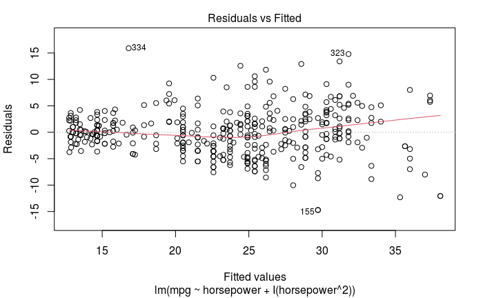

```r
plot(lm(mpg ~ horsepower + I(horsepower^2), data = Auto), which = 1)
```

*(see Figure 3.9 in ISLR for the same plots and discussion)*

#### Normal-QQ Plot

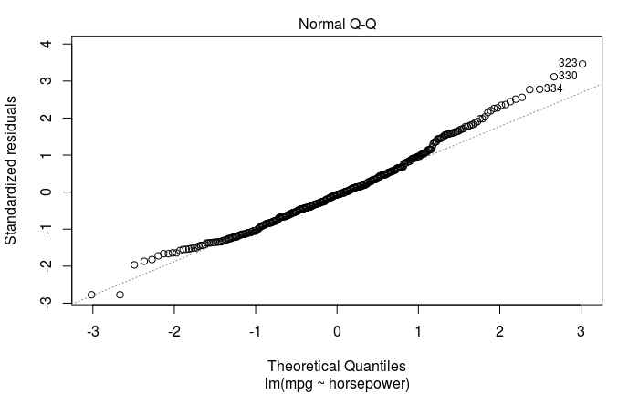

```r
#lindia::gg_qqplot(mod1)
plot(mod1, which = 2)
```

A Normal Q-Q plot shows if residuals are normally distributed. As the residuals in the above plot follow a straight line we can say they look to be normally distributed.

#### Scale-Location Plot

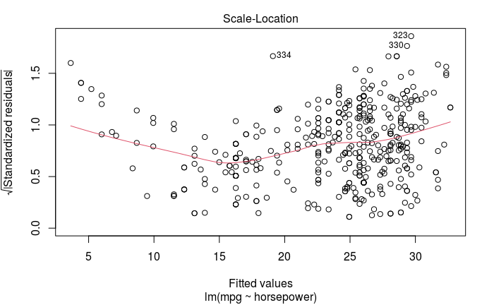

```r
#lindia::gg_scalelocation(mod1) # !NOTE: The axis labels are reversed in this below plot
plot(mod1, which = 3)
```

A scale-location plot can be inspected to see if residuals are spread equally along the ranges of predictors. A horizontal red line with equally (randomly) spread points indicates equal variance of the residuals (homoscedasticity). A non-horizontal trend line and non-random spreading of the residuals indicate non-constant variance (heteroscedasticity). In the above scale-location plot there is a U-shaped trend line, and there appears to be more spread in the residuals in the right-hand half of the plot (larger fitted values). Therefore we can say there appears to be some heteroscedasticity.

#### Residuals Vs Leverage

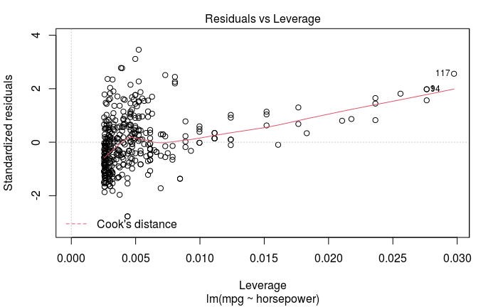

```r
#lindia::gg_resleverage(mod1)
plot(mod1, which = 5)
```

A plot of residuals vs leverage can indicate observations which have excessively high leverage. Such observations are more influential in forming the linear regression model. Instead of inspecting the plot for patterns, we look for points in the upper-right and lower-right corners of the plot. These are observations with both a large residual and large leverage and hence will heavily influence the estimated regression line. In the above plot there are no points with substantially higher leverage than others, and all points have a low leverage value. Note that the red dashed line for Cook’s distance isn’t even visible on the graph indicating that all points fall within acceptable range.

*Aside*  
See page 91 and Table 3.10 in ISLR for discussion on improving the above model with a quadratic fit. In the below summary of such a model we can see how the quadratic fit has an improved R-squared value of 0.688 compared to 0.606 for the linear fit, and the p-value for the quadratic term is highly significant.

```r
mod2 <- lm(mpg ~ horsepower + I(horsepower^2), data = Auto)
summary(mod2)
```

```
Call:
lm(formula = mpg ~ horsepower + I(horsepower^2), data = Auto)

Residuals:
     Min       1Q   Median       3Q      Max
-14.7135  -2.5943  -0.0859   2.2868  15.8961

Coefficients:
                  Estimate Std. Error t value Pr(>|t|)
(Intercept)     56.9000997  1.8004268   31.60   <2e-16 ***
horsepower      -0.4661896  0.0311246  -14.98   <2e-16 ***
I(horsepower^2)  0.0012305  0.0001221   10.08   <2e-16 ***
---
Signif. codes:  0 ‘***’ 0.001 ‘**’ 0.01 ‘*’ 0.05 ‘.’ 0.1 ‘ ’ 1

Residual standard error: 4.374 on 389 degrees of freedom
Multiple R-squared:  0.6876,    Adjusted R-squared:  0.686
F-statistic:   428 on 2 and 389 DF,  p-value: < 2.2e-16
```

If we include all polynomials up to the fifth degree, the fifth degree term also has a significant p-value (see below). However, Figure 3.8 shows how the fifth degree polynomial regression line looks excessively wiggly, and hence it’s not clear that including additional terms beyond the quadratic has really led to a better fit to the data.

```r
mod3 <- lm(mpg ~ poly(horsepower, 5), data = Auto)
summary(mod3)
```

```
Call:
lm(formula = mpg ~ poly(horsepower, 5), data = Auto)

Residuals:
     Min       1Q   Median       3Q      Max
-15.4326  -2.5285  -0.2925   2.1750  15.9730

Coefficients:
                      Estimate Std. Error t value Pr(>|t|)
(Intercept)            23.4459     0.2185 107.308  < 2e-16 ***
poly(horsepower, 5)1 -120.1377     4.3259 -27.772  < 2e-16 ***
poly(horsepower, 5)2   44.0895     4.3259  10.192  < 2e-16 ***
poly(horsepower, 5)3   -3.9488     4.3259  -0.913  0.36190
poly(horsepower, 5)4   -5.1878     4.3259  -1.199  0.23117
poly(horsepower, 5)5   13.2722     4.3259   3.068  0.00231 **
---
Signif. codes:  0 ‘***’ 0.001 ‘**’ 0.01 ‘*’ 0.05 ‘.’ 0.1 ‘ ’ 1

Residual standard error: 4.326 on 386 degrees of freedom
Multiple R-squared:  0.6967,    Adjusted R-squared:  0.6928
F-statistic: 177.4 on 5 and 386 DF,  p-value: < 2.2e-16
```

## Exercise 9

### (a)

```r
Auto
```

|  | mpg | cylinders | displacement | horsepower | weight | acceleration | year | origin | name |
| --- | --- | --- | --- | --- | --- | --- | --- | --- | --- |
| 1 | 18.0 | 8 | 307.0 | 130 | 3504 | 12.0 | 70 | 1 | chevrolet chevelle malibu |
| 2 | 15.0 | 8 | 350.0 | 165 | 3693 | 11.5 | 70 | 1 | buick skylark 320 |
| 3 | 18.0 | 8 | 318.0 | 150 | 3436 | 11.0 | 70 | 1 | plymouth satellite |
| 4 | 16.0 | 8 | 304.0 | 150 | 3433 | 12.0 | 70 | 1 | amc rebel sst |
| 5 | 17.0 | 8 | 302.0 | 140 | 3449 | 10.5 | 70 | 1 | ford torino |
| 6 | 15.0 | 8 | 429.0 | 198 | 4341 | 10.0 | 70 | 1 | ford galaxie 500 |
| 7 | 14.0 | 8 | 454.0 | 220 | 4354 | 9.0 | 70 | 1 | chevrolet impala |
| 8 | 14.0 | 8 | 440.0 | 215 | 4312 | 8.5 | 70 | 1 | plymouth fury iii |
| 9 | 14.0 | 8 | 455.0 | 225 | 4425 | 10.0 | 70 | 1 | pontiac catalina |
| 10 | 15.0 | 8 | 390.0 | 190 | 3850 | 8.5 | 70 | 1 | amc ambassador dpl |

[output cut: 382 more lines]

Update `origin` to be a factor:

```r
Auto <- Auto %>%
  mutate(origin = factor(origin))

is_numeric_col <- map_lgl(Auto, is.numeric)
names(Auto)[is_numeric_col]
```

```
[1] "mpg"          "cylinders"    "displacement" "horsepower"   "weight"       "acceleration" "year"
```

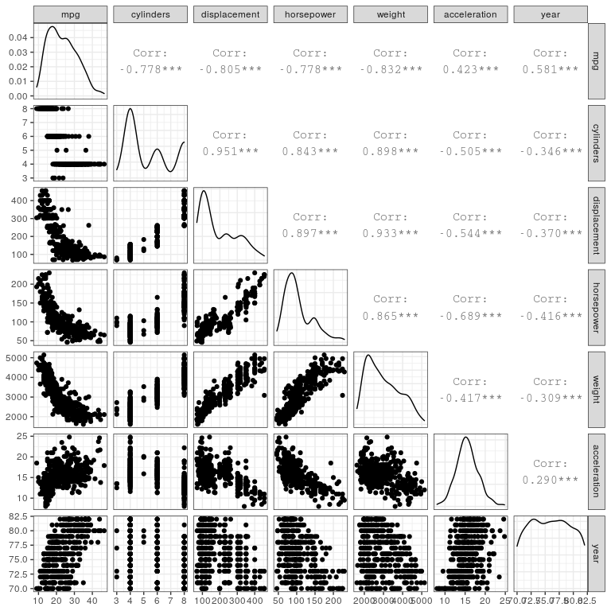

```r
ggpairs(Auto[ , is_numeric_col], progress = FALSE)
```

### (b)

```r
cor(Auto[ , is_numeric_col]) %>% round(3)
```

```
                mpg cylinders displacement horsepower weight acceleration   year
mpg           1.000    -0.778       -0.805     -0.778 -0.832        0.423  0.581
cylinders    -0.778     1.000        0.951      0.843  0.898       -0.505 -0.346
displacement -0.805     0.951        1.000      0.897  0.933       -0.544 -0.370
horsepower   -0.778     0.843        0.897      1.000  0.865       -0.689 -0.416
weight       -0.832     0.898        0.933      0.865  1.000       -0.417 -0.309
acceleration  0.423    -0.505       -0.544     -0.689 -0.417        1.000  0.290
year          0.581    -0.346       -0.370     -0.416 -0.309        0.290  1.000
```

### (c)

```r
mod1 <- lm(mpg ~ . -name, data = Auto)
summary(mod1)
```

```
Call:
lm(formula = mpg ~ . - name, data = Auto)

Residuals:
    Min      1Q  Median      3Q     Max
-9.0095 -2.0785 -0.0982  1.9856 13.3608

Coefficients:
               Estimate Std. Error t value Pr(>|t|)
(Intercept)  -1.795e+01  4.677e+00  -3.839 0.000145 ***
cylinders    -4.897e-01  3.212e-01  -1.524 0.128215
displacement  2.398e-02  7.653e-03   3.133 0.001863 **
horsepower   -1.818e-02  1.371e-02  -1.326 0.185488
weight       -6.710e-03  6.551e-04 -10.243  < 2e-16 ***
acceleration  7.910e-02  9.822e-02   0.805 0.421101
year          7.770e-01  5.178e-02  15.005  < 2e-16 ***
origin2       2.630e+00  5.664e-01   4.643 4.72e-06 ***
origin3       2.853e+00  5.527e-01   5.162 3.93e-07 ***
---
Signif. codes:  0 ‘***’ 0.001 ‘**’ 0.01 ‘*’ 0.05 ‘.’ 0.1 ‘ ’ 1

Residual standard error: 3.307 on 383 degrees of freedom
Multiple R-squared:  0.8242,    Adjusted R-squared:  0.8205
F-statistic: 224.5 on 8 and 383 DF,  p-value: < 2.2e-16
```

### (i)

Yes. The model has an F-statistic of 224.5 which is well above 1 and has a very low p-value. This indicates a relationship between the predictors and the response.

### (ii)

The predictors `weight`, `year`, `origin2` and `origin3` all have very low p-values indicating a statistically significant relationship to the response. The `displacement` predictor also has a low p-value and hence a statistically significant relationship to the response. The predictors `cylinders`, `horsepower` and `acceleration` do not have a statistically significant relationship to the response.

### (iii)

The coefficient for the `year` variable is 0.777. This means that, on average, when the other variables are held constant, an increase of one year (of production) corresponds to an increase of 0.777 of mpg. That is to say, newer cars tend to be more fuel efficient.

### (d)

*Parts of this section are adapted from: https://data.library.virginia.edu/diagnostic-plots/ which has a nice explanation of residuals plots.)*

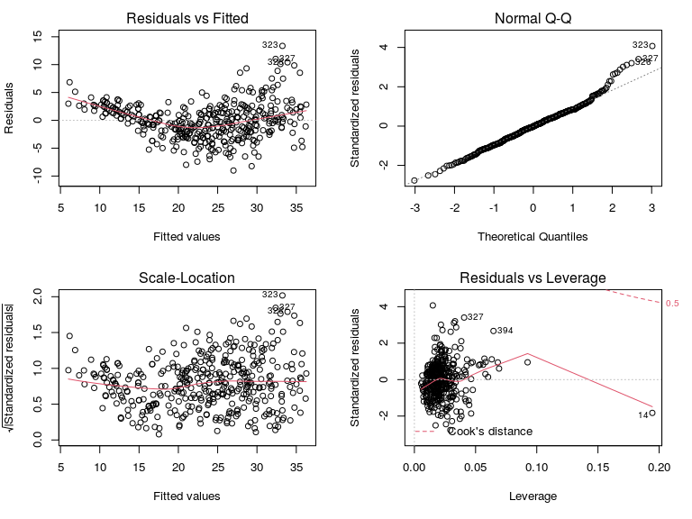

```r
#plot_lm_diagnostics(mod1) # There are issues with these plots, use base R instead
par(mfrow = c(2, 2))
plot(mod1)
```

#### Residuals vs Fitted Value

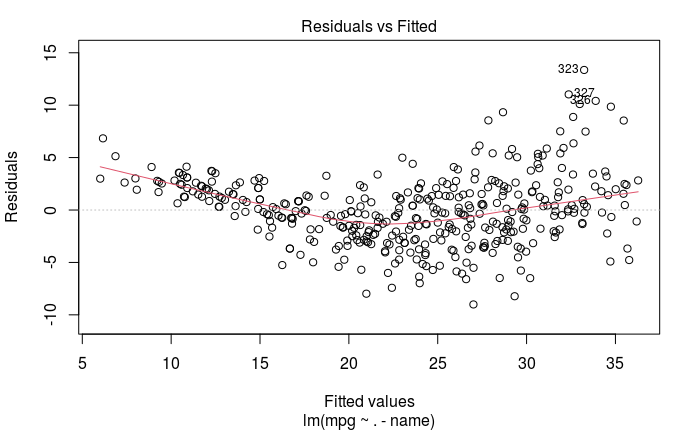

```r
#lindia::gg_resfitted(mod1)
plot(mod1, which = 1)
```

The residual vs fitted values plot seems to show a non-linear trend in the residuals. Additionally there appears to be more spread in the residuals on the right-hand side of the plot (funnel shape). That is to say there appears to be more variance in the residuals for observations with higher fitted values (heteroscedasticity).

There doesn’t appear to be any **outliers** on the plot.

#### Normal-QQ Plot

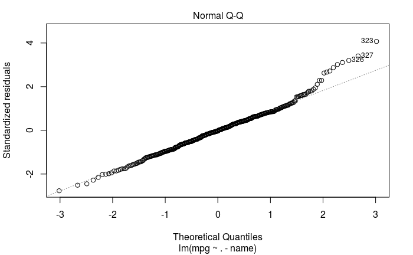

```r
#lindia::gg_qqplot(mod1) # The y-axis seems to be off compared to the base R plot
plot(mod1, which = 2)
```

In the normal Q-Q plot most of the residuals appear to fit the line well. There does however seem to be a deviation at one end, with an excess of residuals with value greater than 3.

#### Scale-Location Plot

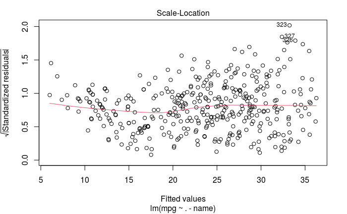

```r
#lindia::gg_scalelocation(mod1) # !NOTE: The axis labels are reversed in this below plot
plot(mod1, which = 3)
```

A scale-location plot can be inspected to see if residuals are spread equally along the ranges of predictors. A horizontal red line with equally (randomly) spread points indicates equal variance of the residuals (homoscedasticity). A non-horizontal trend line and non-random spreading of the residuals indicate non-constant variance (heteroscedasticity). In the above scale-location plot there does not appear to be a strong trend or shape to the red line, which is close to horizontal. There does however appear to be more spread in the residuals in the right-hand half of the plot (larger fitted values). It’s not immediately clear from the plot if there is heteroscedasticity.

#### Residuals Vs Leverage

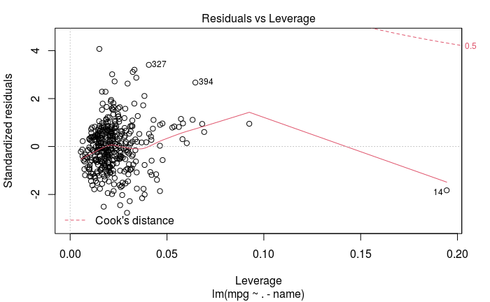

```r
#lindia::gg_resleverage(mod1)
plot(mod1, which = 5)
```

A plot of residuals vs leverage can indicate observations which have excessively high leverage. Such observations are more influential in forming the linear regression model. Instead of inspecting the plot for patterns, we look for points in the upper-right and lower-right corners of the plot. These are observations with both a large residual and large leverage and hence will heavily influence the estimated regression line. In the above plot there is one point with substantially higher leverage than others. However this point does not have a high residual, and is far away from the line for Cook’s distance of 0.5. All other points have a low leverage value.

### (e)

From the correlation matrix, we obtain the two highest correlated pairs (`cylinders` and `displacement`, `weight` and `displacement`) and fit a model including their interaction effects:

```r
mod2 <- lm(mpg ~ cylinders*displacement + weight*displacement, data = Auto)
summary(mod2)
```

```
Call:
lm(formula = mpg ~ cylinders * displacement + weight * displacement,
    data = Auto)

Residuals:
     Min       1Q   Median       3Q      Max
-13.2934  -2.5184  -0.3476   1.8399  17.7723

Coefficients:
                         Estimate Std. Error t value Pr(>|t|)
(Intercept)             5.262e+01  2.237e+00  23.519  < 2e-16 ***
cylinders               7.606e-01  7.669e-01   0.992    0.322
displacement           -7.351e-02  1.669e-02  -4.403 1.38e-05 ***
weight                 -9.888e-03  1.329e-03  -7.438 6.69e-13 ***
cylinders:displacement -2.986e-03  3.426e-03  -0.872    0.384
displacement:weight     2.128e-05  5.002e-06   4.254 2.64e-05 ***
---
Signif. codes:  0 ‘***’ 0.001 ‘**’ 0.01 ‘*’ 0.05 ‘.’ 0.1 ‘ ’ 1

Residual standard error: 4.103 on 386 degrees of freedom
Multiple R-squared:  0.7272,    Adjusted R-squared:  0.7237
F-statistic: 205.8 on 5 and 386 DF,  p-value: < 2.2e-16
```

From the p-values, we can see that the interaction between `displacement` and `weight` is statistically significant, while the interaction between `cylinders` and `displacement` is not.

Now consider two negatively correlated variables, `year` and `horsepower`. Fit a model which includes the significant predictors from the first model, as well as an interaction term for `year` and `horsepower`:

```r
mod3 <- lm(mpg ~ displacement + weight + origin + year*horsepower, data=Auto)
summary(mod3)
```

```
Call:
lm(formula = mpg ~ displacement + weight + origin + year * horsepower,
    data = Auto)

Residuals:
    Min      1Q  Median      3Q     Max
-8.0369 -1.9621 -0.0509  1.5762 11.9235

Coefficients:
                  Estimate Std. Error t value Pr(>|t|)
(Intercept)     -9.775e+01  9.633e+00 -10.147  < 2e-16 ***
displacement     1.101e-02  5.259e-03   2.094   0.0369 *
weight          -5.616e-03  5.316e-04 -10.563  < 2e-16 ***
origin2          2.407e+00  5.155e-01   4.669 4.20e-06 ***
origin3          2.374e+00  5.026e-01   4.724 3.24e-06 ***
year             1.845e+00  1.272e-01  14.508  < 2e-16 ***
horsepower       7.988e-01  9.126e-02   8.753  < 2e-16 ***
year:horsepower -1.127e-02  1.244e-03  -9.057  < 2e-16 ***
---
Signif. codes:  0 ‘***’ 0.001 ‘**’ 0.01 ‘*’ 0.05 ‘.’ 0.1 ‘ ’ 1

Residual standard error: 3.01 on 384 degrees of freedom
Multiple R-squared:  0.854, Adjusted R-squared:  0.8513
F-statistic: 320.8 on 7 and 384 DF,  p-value: < 2.2e-16
```

Now fit a model which includes interactions between all predictors that were significant in the first model. We will also include `horsepower` as this was found to have a significant interaction with `year`:

```r
mod4 <- lm(mpg ~ (displacement + horsepower + weight + year + origin)^2, data = Auto)
summary(mod4)
```

```
Call:
lm(formula = mpg ~ (displacement + horsepower + weight + year +
    origin)^2, data = Auto)

Residuals:
    Min      1Q  Median      3Q     Max
-7.7596 -1.5012 -0.0569  1.3299 12.4205

Coefficients:
                          Estimate Std. Error t value Pr(>|t|)
(Intercept)             -4.989e+01  2.404e+01  -2.075 0.038688 *
displacement            -1.341e-01  1.222e-01  -1.097 0.273147
horsepower               9.686e-01  2.288e-01   4.233 2.91e-05 ***
weight                  -2.144e-02  1.607e-02  -1.334 0.183063
year                     1.363e+00  2.976e-01   4.579 6.38e-06 ***
origin2                 -1.180e+01  1.068e+01  -1.105 0.269847
origin3                 -8.132e+00  1.087e+01  -0.748 0.455003
displacement:horsepower -2.259e-04  1.363e-04  -1.657 0.098373 .
displacement:weight      3.113e-05  6.042e-06   5.152 4.20e-07 ***
displacement:year        8.098e-04  1.482e-03   0.547 0.584998
displacement:origin2    -4.495e-02  3.613e-02  -1.244 0.214267
displacement:origin3     7.915e-02  2.674e-02   2.960 0.003271 **
horsepower:weight       -1.107e-05  1.808e-05  -0.612 0.540840
horsepower:year         -1.193e-02  2.823e-03  -4.227 2.99e-05 ***
horsepower:origin2      -1.170e-01  3.186e-02  -3.673 0.000275 ***
horsepower:origin3      -5.913e-02  4.719e-02  -1.253 0.210981
weight:year              1.284e-04  1.955e-04   0.656 0.511963
weight:origin2           5.547e-03  1.880e-03   2.951 0.003370 **
weight:origin3          -2.640e-03  2.772e-03  -0.952 0.341572
year:origin2             1.819e-01  1.386e-01   1.313 0.190054
year:origin3             1.441e-01  1.395e-01   1.033 0.302155
---
Signif. codes:  0 ‘***’ 0.001 ‘**’ 0.01 ‘*’ 0.05 ‘.’ 0.1 ‘ ’ 1

Residual standard error: 2.703 on 371 degrees of freedom
Multiple R-squared:  0.8862,    Adjusted R-squared:   0.88
F-statistic: 144.4 on 20 and 371 DF,  p-value: < 2.2e-16
```

We can see a number of the interaction terms are significant, including the `horsepower:year` and `displacement:weight` terms from the previous models. Interestingly, the first order terms `displacement`, `weight` and `origin2` and `origin3` are no longer significant. Per the hierarchy principle (page 89), we should include main effects in the model if we find that their interaction terms are significant. Also, the first order `horespower` term is now significant, even though it wasn’t in the first model. This model has an R-squared value of 0.8862 which is an improvement on the previous models. Further investigation of interaction terms would be required to obtain an optimal model.

### (f)

The `horsepower` variable was statistically significant in the simple linear regression model in Exercise 8, but not in the multiple linear regression model in Exercise 9 part (c). A non-linear transformation of the variable may produce interesting results. From inspection of the plot it looks like `horsepower` and `mpg` have a non-linear relationship. The below plots show `mpg` plotted against `horsepower` and its log, square root, and quadratic transformations:

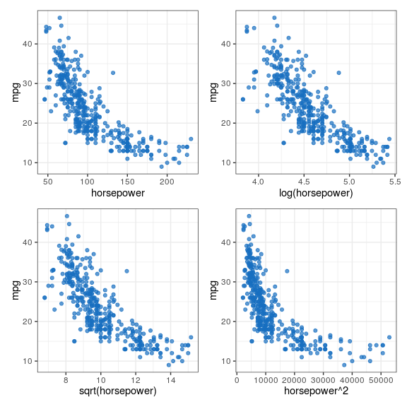

```r
p1 <- ggplot(Auto, aes(horsepower, mpg)) +
  geom_point(color = ISLR_blue, alpha = 0.7)

p2 <- ggplot(Auto, aes(log(horsepower), mpg)) +
  geom_point(color = ISLR_blue, alpha = 0.7)

p3 <- ggplot(Auto, aes(sqrt(horsepower), mpg)) +
  geom_point(color = ISLR_blue, alpha = 0.7)

p4 <- ggplot(Auto, aes(horsepower^2, mpg)) +
  geom_point(color = ISLR_blue, alpha = 0.7)

p1 + p2 + p3 + p4
```

It seems that the log transformation gives the most linear looking plot. Now fit an updated model combining the statistically significant variables from the earlier model with the log-transformation of `horsepower`:

```r
mod5 <- lm(mpg ~ displacement + weight + year + origin + log(horsepower), data = Auto)
summary(mod5)
```

```
Call:
lm(formula = mpg ~ displacement + weight + year + origin + log(horsepower),
    data = Auto)

Residuals:
    Min      1Q  Median      3Q     Max
-8.7090 -1.9940 -0.1527  1.9211 12.8008

Coefficients:
                  Estimate Std. Error t value Pr(>|t|)
(Intercept)      8.2458760  6.2653580   1.316 0.188921
displacement     0.0198033  0.0051511   3.844 0.000141 ***
weight          -0.0057339  0.0005748  -9.976  < 2e-16 ***
year             0.7410175  0.0498839  14.855  < 2e-16 ***
origin2          2.5304188  0.5397268   4.688 3.83e-06 ***
origin3          2.9789826  0.5193697   5.736 1.97e-08 ***
log(horsepower) -6.3030948  1.1086746  -5.685 2.58e-08 ***
---
Signif. codes:  0 ‘***’ 0.001 ‘**’ 0.01 ‘*’ 0.05 ‘.’ 0.1 ‘ ’ 1

Residual standard error: 3.199 on 385 degrees of freedom
Multiple R-squared:  0.8345,    Adjusted R-squared:  0.832
F-statistic: 323.6 on 6 and 385 DF,  p-value: < 2.2e-16
```

We see that the log transformation of the `horsepower` predictor is statistically significant, and there is a marginally improved R-squared of 0.8345 (compared to 0.8242 for `mod1`).

## Exercise 10

### (a)

```r
Carseats
```

|  | Sales | CompPrice | Income | Advertising | Population | Price | ShelveLoc | Age | Education | Urban | US |
| --- | --- | --- | --- | --- | --- | --- | --- | --- | --- | --- | --- |
| 1 | 9.50 | 138 | 73 | 11 | 276 | 120 | Bad | 42 | 17 | Yes | Yes |
| 2 | 11.22 | 111 | 48 | 16 | 260 | 83 | Good | 65 | 10 | Yes | Yes |
| 3 | 10.06 | 113 | 35 | 10 | 269 | 80 | Medium | 59 | 12 | Yes | Yes |
| 4 | 7.40 | 117 | 100 | 4 | 466 | 97 | Medium | 55 | 14 | Yes | Yes |
| 5 | 4.15 | 141 | 64 | 3 | 340 | 128 | Bad | 38 | 13 | Yes | No |
| 6 | 10.81 | 124 | 113 | 13 | 501 | 72 | Bad | 78 | 16 | No | Yes |
| 7 | 6.63 | 115 | 105 | 0 | 45 | 108 | Medium | 71 | 15 | Yes | No |
| 8 | 11.85 | 136 | 81 | 15 | 425 | 120 | Good | 67 | 10 | Yes | Yes |
| 9 | 6.54 | 132 | 110 | 0 | 108 | 124 | Medium | 76 | 10 | No | No |
| 10 | 4.69 | 132 | 113 | 0 | 131 | 124 | Medium | 76 | 17 | No | Yes |

[output cut: 390 more lines]

```r
mod1 <- lm(Sales ~ Price + Urban + US, data = Carseats)
summary(mod1)
```

```
Call:
lm(formula = Sales ~ Price + Urban + US, data = Carseats)

Residuals:
    Min      1Q  Median      3Q     Max
-6.9206 -1.6220 -0.0564  1.5786  7.0581

Coefficients:
             Estimate Std. Error t value Pr(>|t|)
(Intercept) 13.043469   0.651012  20.036  < 2e-16 ***
Price       -0.054459   0.005242 -10.389  < 2e-16 ***
UrbanYes    -0.021916   0.271650  -0.081    0.936
USYes        1.200573   0.259042   4.635 4.86e-06 ***
---
Signif. codes:  0 ‘***’ 0.001 ‘**’ 0.01 ‘*’ 0.05 ‘.’ 0.1 ‘ ’ 1

Residual standard error: 2.472 on 396 degrees of freedom
Multiple R-squared:  0.2393,    Adjusted R-squared:  0.2335
F-statistic: 41.52 on 3 and 396 DF,  p-value: < 2.2e-16
```

### (c)

Our model takes the form:
$$Y=\beta_{0}+\beta_{1}X_{1}+\beta_{2}X_{2}+\beta_{3}X_{3}+\epsilon$$
where $X_{1}$ is the `Price` variable, and $X_{2}$ and $X_{3}$ are dummy variables, used to encode the `Urban` and `US` variables respectively:
$$x_{i2} =\begin{cases}1 & \text{if }i\text{th store is Urban}\\0 & \text{if }i\text{th store is Rural}\end{cases}$$
$$x_{i3} =\begin{cases}1 & \text{if }i\text{th store is in US}\\0 & \text{if }i\text{th store is non-US}\end{cases}$$
We can use these dummy variables as predictors in the regression equation:
$$y_{i} = \beta _{0}+\beta _{1}x _{i1}+\beta_{2}x_{i2}+\beta_{3}x_{i3} +\epsilon_{i}=\begin{cases}\beta _{0}+\beta_{1}x_{i1}+\epsilon_{i} & \text{if }i\text{th store is Rural and Non-US}\\\beta _{0}+\beta_{1}x_{i1}+\beta_{2}+\epsilon_{i} & \text{if }i\text{th store is Urban and Non-US}\\\beta _{0}+\beta_{1}x_{i1}+\beta_{3}+\epsilon_{i} & \text{if }i\text{th store is Rural and in US}\\\beta _{0}+\beta_{1}x_{i1}+\beta_{2}+\beta_{3}+\epsilon_{i} & \text{if }i\text{th store is Urban and in US}\end{cases}$$
Using the values from the model we have:
$$\hat{y} = -0.05*\texttt{price}+\begin{cases}13.04 & \texttt{UrbanYes}=0, \texttt{USYes}=0\\13.02 & \texttt{UrbanYes}=1, \texttt{USYes}=0\\14.24 & \texttt{UrbanYes}=0, \texttt{USYes}=1\\14.22 & \texttt{UrbanYes}=1, \texttt{USYes}=1\end{cases}$$

Calculations:

```r
13.04 # Intercept
```

```
[1] 13.04
```

```r
13.04 - 0.022 # Intercept + beta1
```

```
[1] 13.018
```

```r
13.04 + 1.201 # Intercept + beta2
```

```
[1] 14.241
```

```r
13.04 - 0.022 + 1.201 # Intercept + beta1 + beta2
```

```
[1] 14.219
```

### (d)

The variables `Price` and `USYes` have low p-values indicating a statistically significant relationship with the response. We can reject the null hypothesis that the $\beta$-coefficient for these predictors is zero.

### (e)

```r
mod2 <- lm(Sales ~ Price + US, data = Carseats)
summary(mod2)
```

```
Call:
lm(formula = Sales ~ Price + US, data = Carseats)

Residuals:
    Min      1Q  Median      3Q     Max
-6.9269 -1.6286 -0.0574  1.5766  7.0515

Coefficients:
            Estimate Std. Error t value Pr(>|t|)
(Intercept) 13.03079    0.63098  20.652  < 2e-16 ***
Price       -0.05448    0.00523 -10.416  < 2e-16 ***
USYes        1.19964    0.25846   4.641 4.71e-06 ***
---
Signif. codes:  0 ‘***’ 0.001 ‘**’ 0.01 ‘*’ 0.05 ‘.’ 0.1 ‘ ’ 1

Residual standard error: 2.469 on 397 degrees of freedom
Multiple R-squared:  0.2393,    Adjusted R-squared:  0.2354
F-statistic: 62.43 on 2 and 397 DF,  p-value: < 2.2e-16
```

### (f)

The adjusted R-squared value for the second model is slightly larger, 0.2354 vs 0.2335. This means that removing the `Urban` variable has had a small effect on the model. The R-squared value of 0.2393 means the model only accounts for approximately 24% of the variability in the data. However, the two variables included in the second model do show evidence of association with the response. The F-test in both models has a p-value of essentially zero.

### (g)

Calculate 95% confidence intervals for the coefficients:

```r
confint(mod2)
```

```
                  2.5 %      97.5 %
(Intercept) 11.79032020 14.27126531
Price       -0.06475984 -0.04419543
USYes        0.69151957  1.70776632
```

### (h)

The below diagnostic plots do not show any outliers in the data. There are some points with high leverage. The point with highest leverage has a near-zero residual.

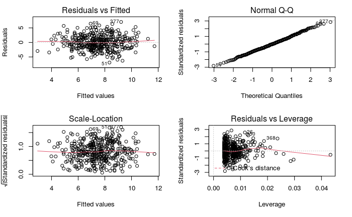

```r
par(mfrow = c(2, 2))
plot(mod2)
```

A closer look at the residual plot to check for outliers (no red points means no outliers).

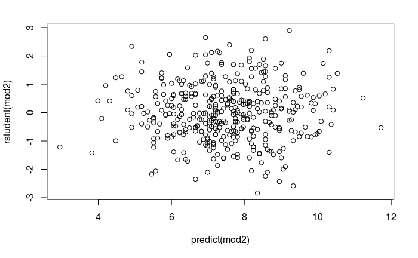

```r
plot(predict(mod2), rstudent(mod2), col = ifelse(rstudent(mod2) > 3, "red", "black"))
```

A closer look at the leverage plot to check for high leverage points (highlighted in red):

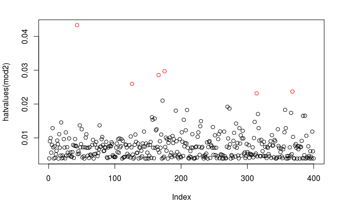

```r
plot(hatvalues(mod2), col = ifelse(hatvalues(mod2) > (2+1)/nrow(Carseats)*3, "red", "black"))
```

## Exercise 11

```r
set.seed(1)
x <- rnorm(100)
y <- 2*x + rnorm(100)
```

### (a)

```r
mod1 <- lm(y ~ x + 0)
summary(mod1)
```

```
Call:
lm(formula = y ~ x + 0)

Residuals:
    Min      1Q  Median      3Q     Max
-1.9154 -0.6472 -0.1771  0.5056  2.3109

Coefficients:
  Estimate Std. Error t value Pr(>|t|)
x   1.9939     0.1065   18.73   <2e-16 ***
---
Signif. codes:  0 ‘***’ 0.001 ‘**’ 0.01 ‘*’ 0.05 ‘.’ 0.1 ‘ ’ 1

Residual standard error: 0.9586 on 99 degrees of freedom
Multiple R-squared:  0.7798,    Adjusted R-squared:  0.7776
F-statistic: 350.7 on 1 and 99 DF,  p-value: < 2.2e-16
```

Null Hypothesis $H_{0}:\beta=0$

- Coefficient estimate $\hat{\beta}$ = `1.9939`
- Standard error of $\hat{\beta}$ = `0.1065`
- t-statistic associated with $H_{0}$ = `18.73`
- p-value associated with $H_{0}$ is < `2.2e-16`

The coefficient estimate suggests `y` is positively correlated with `x`. The t-statistic and corresponding p-value suggest we can reject the null hypothesis and conclude that there is evidence for a relationship between `x` and `y`.

### (b)

```r
mod2 <- lm(x ~ y + 0)
summary(mod2)
```

```
Call:
lm(formula = x ~ y + 0)

Residuals:
    Min      1Q  Median      3Q     Max
-0.8699 -0.2368  0.1030  0.2858  0.8938

Coefficients:
  Estimate Std. Error t value Pr(>|t|)
y  0.39111    0.02089   18.73   <2e-16 ***
---
Signif. codes:  0 ‘***’ 0.001 ‘**’ 0.01 ‘*’ 0.05 ‘.’ 0.1 ‘ ’ 1

Residual standard error: 0.4246 on 99 degrees of freedom
Multiple R-squared:  0.7798,    Adjusted R-squared:  0.7776
F-statistic: 350.7 on 1 and 99 DF,  p-value: < 2.2e-16
```

Null Hypothesis $H_{0}:\beta=0$

- Coefficient estimate $\hat{\beta}$ = `0.391`
- Standard error of $\hat{\beta}$ = `0.021`
- t-statistic associated with $H_{0}$ = `18.73`
- p-value associated with $H_{0}$ is < `2.2e-16`

The coefficient estimate suggests `x` is positively correlated with `y`. The t-statistic and corresponding p-value suggest we can reject the null hypothesis and conclude that there is evidence for a relationship between `x` and `y`.

### (c)

The F-statistic and R-squared value are the same in both cases. In (a) the equation is $y = 2x + \epsilon$, and our $\beta$-coefficient is very close to the true value ($\beta = 2$, $\hat{\beta} = 1.9939$). In (b) the equation is $x = 0.5(y - \epsilon)$ and our $\beta$-coefficient reflects this ($\hat{\beta} = 0.391$) but it’s not as close to the true value as the model in (a) due to noise that was added to `y` when generating the data (set `sd` to a small value when creating `y` to reduce noise).

The models can be viewed on plots:

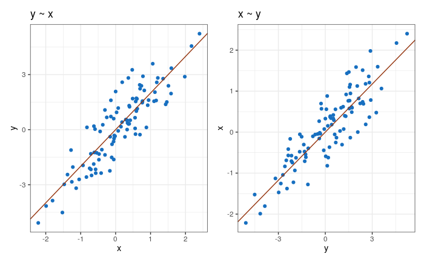

```r
p1 <- data.frame(x, y) %>%
  ggplot() +
  geom_point(aes(x, y),
             color = ISLR_blue) +
  geom_abline(intercept = 0, slope = coef(summary(mod1))[1],
              color = ISLR_brown) +
  ggtitle("y ~ x")

p2 <- data.frame(x, y) %>%
  ggplot() +
  geom_point(aes(y, x),
             color = ISLR_blue) +
  geom_abline(intercept = 0, slope = coef(summary(mod2))[1],
              color = ISLR_brown) +
  ggtitle("x ~ y")

p1 + p2
```

### (d)

For the regression of $Y$ onto $X$ without an intercept, the t-statistic for $H_{0}:\beta=0$ takes the form $\hat{\beta}/\text{SE}(\hat{\beta})$, where

$$\hat{\beta} ~=~ \frac{\sum_{i=1}^nx_{i}y_{i}}{\sum_{i'=1}^n(x_{i'})^2}, \hspace{2cm} (3.38)$$
$$\text{SE}(\hat{\beta})=\sqrt{\frac{\sum_{i=1}^n(y_{i}-x_{i}\hat{\beta})^2}{(n-1)\sum_{i'=1}^n(x_{i'})^2}}.$$

#### *Algebraic proof:*

**To prove**
Show that
$$t = \hat{\beta}/\text{SE}(\hat{\beta}) = \frac{(\sqrt{n-1})\sum_{i=1}^nx_{i}y_{i}}{\sqrt{\sum_{i=1}^n(x_{i})^2\sum_{i'=1}^n(y_{i'})^2-\left(\sum_{i'=1}^nx_{i'}y_{i'}\right)^2}}$$
**Proof**
**(1)**
Let $A$ be equal to the square of the numerator of the expression for $\text{SE}(\hat{\beta})$:

$$A=\sum_{i=1}^n(y_{i}-x_{i}\hat{\beta})^2$$
Expand:
$$A=\sum_{i=1}^n(y_{i}^2-2\hat{\beta}x_{i}y_{i}+\hat{\beta}^2x_{i}^2)$$

Substitute in the expression for $\hat{\beta}_{1}$ (remember to update indexes of the nested sums):
$$A=\sum_{i=1}^n(y_{i}^2-2\frac{\sum_{j=1}^nx_{j}y_{j}}{\sum_{j=1}^n(x_{j})^2}x_{i}y_{i}+\frac{\left(\sum_{j=1}^nx_{j}y_{j}\right)^2}{\left(\sum_{j=1}^n(x_{j})^2\right)^2}x_{i}^2)$$

Expand the sum and rearrange:
$$A=\sum_{i=1}^n(y_{i})^2-2\frac{\sum_{j=1}^nx_{j}y_{j}}{\sum_{j=1}^n(x_{j})^2}\sum_{i=1}^nx_{i}y_{i}+\frac{\left(\sum_{j=1}^nx_{j}y_{j}\right)^2}{\left(\sum_{j=1}^n(x_{j})^2\right)^2}\sum_{i=1}^n(x_{i})^2$$
There are no nested sums, so indexes $i$ and $j$ are the same. Rewrite with index $i$ and rearrange:
$$A=\sum_{i=1}^n(y_{i})^2-2\frac{\left(\sum_{i=1}^nx_{i}y_{i}\right)^2}{\sum_{i=1}^n(x_{i})^2}+\frac{\left(\sum_{i=1}^nx_{i}y_{i}\right)^2\sum_{i=1}^n(x_{i})^2}{\sum_{i=1}^n(x_{i})^2\sum_{i=1}^n(x_{i})^2}$$

Cancel terms and simplify :
$$A=\sum_{i=1}^n(y_{i})^2-\frac{\left(\sum_{i=1}^nx_{i}y_{i}\right)^2}{\sum_{i=1}^n(x_{i})^2}$$
**(2)**
Rewrite $\text{SE}(\hat{\beta})$using the expression derived for $A$:
$$\text{SE}(\hat{\beta})=\sqrt{\sum_{i=1}^n(y_{i})^2-\frac{\left(\sum_{i=1}^nx_{i}y_{i}\right)^2}{\sum_{i=1}^n(x_{i})^2}} \bigg/ \sqrt{(n-1)\sum_{i'=1}^n(x_{i'})^2}$$

**(3)**
$$t=\hat{\beta}/\text{SE}(\hat{\beta})$$
$$t = \left(\frac{\sum_{i=1}^nx_{i}y_{i}}{\sum_{i'=1}^n(x_{i'})^2}\right) . \sqrt{(n-1)\sum_{i'=1}^n(x_{i'})^2} \bigg/ \sqrt{\sum_{i=1}^n(y_{i})^2-\frac{\left(\sum_{i=1}^nx_{i}y_{i}\right)^2}{\sum_{i=1}^n(x_{i})^2}}$$
Rearrange:
$$t = \frac{(\sqrt{n-1})\sum_{i=1}^nx_{i}y_{i}.\sqrt{\sum_{i'=1}^n(x_{i'})^2}}{\sum_{i'=1}^n(x_{i'})^2} \bigg/ \sqrt{\frac{\sum_{i=1}^n(x_{i})^2\sum_{i=1}^n(y_{i})^2-\left(\sum_{i=1}^nx_{i}y_{i}\right)^2}{\sum_{i=1}^n(x_{i})^2}}$$
$$t = \frac{(\sqrt{n-1})\sum_{i=1}^nx_{i}y_{i}.\sqrt{\sum_{i'=1}^n(x_{i'})^2}}{\sum_{i'=1}^n(x_{i'})^2} \bigg/ \frac{\sqrt{\sum_{i=1}^n(x_{i})^2\sum_{i=1}^n(y_{i})^2-\left(\sum_{i=1}^nx_{i}y_{i}\right)^2}}{\sqrt{\sum_{i=1}^n(x_{i})^2}}$$

$$t = \frac{(\sqrt{n-1})\sum_{i=1}^nx_{i}y_{i}.\sqrt{\sum_{i'=1}^n(x_{i'})^2} . \sqrt{\sum_{i=1}^n(x_{i})^2}}{\sum_{i'=1}^n(x_{i'})^2 . \sqrt{\sum_{i=1}^n(x_{i})^2\sum_{i=1}^n(y_{i})^2-\left(\sum_{i=1}^nx_{i}y_{i}\right)^2}}$$
$$t = \frac{(\sqrt{n-1})\sum_{i=1}^nx_{i}y_{i}}{\sqrt{\sum_{i=1}^n(x_{i})^2\sum_{i=1}^n(y_{i})^2-\left(\sum_{i=1}^nx_{i}y_{i}\right)^2}} \hspace{2cm} \square$$

#### *Numerical demonstration:*

Returning to the model from part (a) we inspect the summary:

```r
summary(mod1)
```

```
Call:
lm(formula = y ~ x + 0)

Residuals:
    Min      1Q  Median      3Q     Max
-1.9154 -0.6472 -0.1771  0.5056  2.3109

Coefficients:
  Estimate Std. Error t value Pr(>|t|)
x   1.9939     0.1065   18.73   <2e-16 ***
---
Signif. codes:  0 ‘***’ 0.001 ‘**’ 0.01 ‘*’ 0.05 ‘.’ 0.1 ‘ ’ 1

Residual standard error: 0.9586 on 99 degrees of freedom
Multiple R-squared:  0.7798,    Adjusted R-squared:  0.7776
F-statistic: 350.7 on 1 and 99 DF,  p-value: < 2.2e-16
```

The model returns a t-statistic associated with $H_{0}$ of `18.73`.

Calculate the t-statistic using the formula and compare:

```r
n = 100
t = (sqrt(n-1)*sum(x*y)) / sqrt(sum(x^2)*sum(y^2) - sum(x*y)^2)
round(t, 3)
```

```
[1] 18.726
```

The value for the t-statistic given by the formula matches that returned by the model.

### (e)

Rewrite the formula for the t-statistic for the regression of `x` onto `y` and calculate `t` (swap `x` and `y`):

```r
t = (sqrt(n-1)*sum(y*x)) / sqrt(sum(y^2)*sum(x^2) - sum(y*x)^2)
round(t, 3)
```

```
[1] 18.726
```

The value for the t-statistic is the same as in part (d).

### (f)

```r
set.seed(1)
x = rnorm(100)
y = 2 * x + rnorm(100)
mod3 <- lm(y ~ x) # y onto x
mod4 <- lm(x ~ y) # x onto y
paste0("t-statistic for y onto x: ", round(coef(summary(mod3))[2, 3], 3))
```

```
[1] "t-statistic for y onto x: 18.556"
```

```r
paste0("t-statistic for x onto y: ", round(coef(summary(mod4))[2, 3], 3))
```

```
[1] "t-statistic for x onto y: 18.556"
```

The t-statistics are the same for each model.

## Exercise 12

### (a)

The coefficient estimate $\hat{\beta}$̂ for the linear regression of $Y$ onto $X$ without an intercept ($i$th fitted value given by $\hat{y}_{i}=x_{i}\hat{\beta}$):
$$\hat{\beta}=\left(\sum_{i=1}^nx_{i}y_{i}\right) \bigg/ \left(\sum_{i'=1}^nx_{i'}^2\right)$$
The coefficient estimate $\hat{\beta}$̂ for the linear regression of $X$ onto $Y$ without an intercept ($i$th fitted value given by $\hat{x}_{i}=y_{i}\hat{\beta}$):
$$\hat{\beta}=\left(\sum_{i=1}^ny_{i}x_{i}\right) \bigg/ \left(\sum_{i'=1}^ny_{i'}^2\right)$$

Clearly the numerators are equal, so the coefficients are equal when the denominators are also equal:
$$\sum_{i=1}^nx_{i}^2=\sum_{i=1}^ny_{i}^2.$$

### (b)

Generate data where the coefficient estimates are **different** using the equation:
$$Y = 2X + \epsilon$$

```r
set.seed(123)
x <- rnorm(100)
y <- 2*x + rnorm(100, sd = 0.1)

coef(lm(y ~ x + 0))[1]
```

```
       x
1.993637
```

```r
coef(lm(x ~ y + 0))[1]
```

```
       y
0.500185
```

For the regression of `Y` onto `X` the coefficient is ~`2`.

For the regression of `X` onto `Y` the coefficient is ~`0.5`.

### (c)

Generate data where the coefficient estimates are **the same** using the equation:
$$Y = -X + \epsilon$$

```r
set.seed(123)
x <- rnorm(100)
y <- -x + rnorm(100, sd = 0.1)

coef(lm(y ~ x + 0))[1]
```

```
        x
-1.006363
```

```r
coef(lm(x ~ y + 0))[1]
```

```
         y
-0.9827988
```

Both coefficients are approximately `-1`.

## Exercise 13

```r
set.seed(1)
```

### (a)

$X \sim \mathcal{N}(0,1)$:

```r
x <- rnorm(100, mean = 0, sd = 1)
```

### (b)

$\epsilon \sim \mathcal{N}(0,0.25)$:

```r
eps <- rnorm(100, mean = 0, sd = sqrt(0.25))
```

### (c)

$Y = -1 + 0.5X + \epsilon$:

```r
y <- -1 + 0.5*x + eps
```

The length of `y` is the same as `x` and `eps`, which is `100`; $\beta_0 = -1$; $\beta_1 = 0.5$.

### (d)

There is a weak positive linear relationship between `x` and `y`:

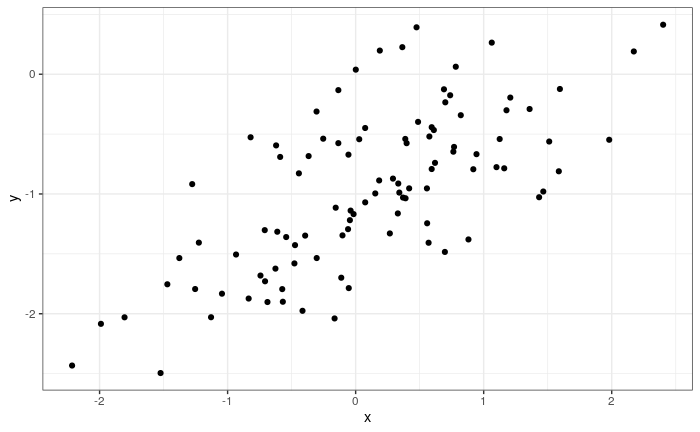

```r
data.frame(x, y) %>%
  ggplot(aes(x, y)) +
  geom_point(color = "black")
```

### (e)

$\hat{Y} = \hat{\beta_0} + \hat{\beta_1}X$:

```r
mod1 <- lm(y ~ x)
summary(mod1)
```

```
Call:
lm(formula = y ~ x)

Residuals:
     Min       1Q   Median       3Q      Max
-0.93842 -0.30688 -0.06975  0.26970  1.17309

Coefficients:
            Estimate Std. Error t value Pr(>|t|)
(Intercept) -1.01885    0.04849 -21.010  < 2e-16 ***
x            0.49947    0.05386   9.273 4.58e-15 ***
---
Signif. codes:  0 ‘***’ 0.001 ‘**’ 0.01 ‘*’ 0.05 ‘.’ 0.1 ‘ ’ 1

Residual standard error: 0.4814 on 98 degrees of freedom
Multiple R-squared:  0.4674,    Adjusted R-squared:  0.4619
F-statistic: 85.99 on 1 and 98 DF,  p-value: 4.583e-15
```

The estimate for the intercept ($\hat{\beta_0} = -1.01885$) and slope ($\hat{\beta_1} = 0.49947$) are very close to the true values of $\beta_0 = -1$ and $\beta_1 = 0.5$.

### (f)

The least squares line and true population regression line are very similar:

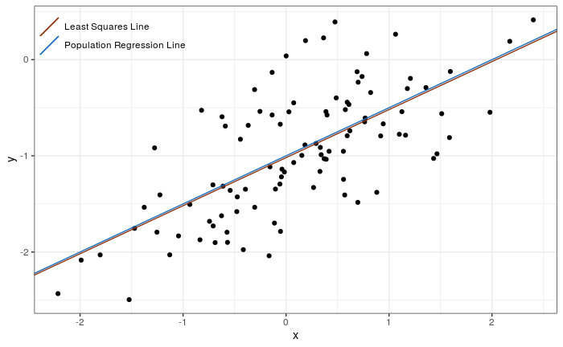

```r
data.frame(x, y) %>%
  ggplot(aes(x, y)) +
  geom_point(color = "black") +
  geom_abline(aes(intercept = coef(mod1)[1], slope = coef(mod1)[2], # least squares line
              color = "Least Squares Line")) +
  geom_abline(aes(intercept = -1, slope = 0.5, # population regression line
              color = "Population Regression Line")) +
  scale_colour_manual(name = NULL,
                      values = c("Least Squares Line" = ISLR_brown,
                                 "Population Regression Line" = ISLR_blue)) +
  theme(legend.position = c(0, 1),
        legend.justification = c(0, 1),
        legend.background = element_blank())
```

### (g)

$\hat{Y} = \hat{\beta_0} + \hat{\beta_1}X + \hat{\beta_2}X^2$:

```r
mod2 <- lm(y ~ x + I(x^2))
summary(mod2)
```

```
Call:
lm(formula = y ~ x + I(x^2))

Residuals:
     Min       1Q   Median       3Q      Max
-0.98252 -0.31270 -0.06441  0.29014  1.13500

Coefficients:
            Estimate Std. Error t value Pr(>|t|)
(Intercept) -0.97164    0.05883 -16.517  < 2e-16 ***
x            0.50858    0.05399   9.420  2.4e-15 ***
I(x^2)      -0.05946    0.04238  -1.403    0.164
---
Signif. codes:  0 ‘***’ 0.001 ‘**’ 0.01 ‘*’ 0.05 ‘.’ 0.1 ‘ ’ 1

Residual standard error: 0.479 on 97 degrees of freedom
Multiple R-squared:  0.4779,    Adjusted R-squared:  0.4672
F-statistic:  44.4 on 2 and 97 DF,  p-value: 2.038e-14
```

Adding the quadratic term has only marginally increased the adjusted R-squared value, 0.4672 versus 0.4619. Additionally, the p-value for the quadratic term is very high, indicating it is not statistically significant.

### (h)

```r
x <- rnorm(100, mean = 0, sd = 1)
eps <- rnorm(100, mean = 0, sd = sqrt(0.1))
y <- -1 + 0.5*x + eps
```

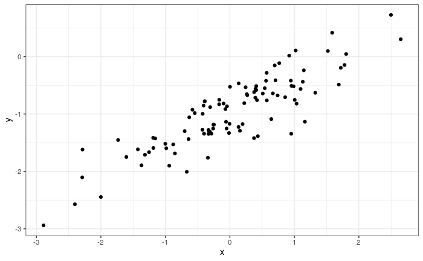

```r
data.frame(x, y) %>%
  ggplot(aes(x, y)) +
  geom_point(color = "black")
```

There is now a clearer linear relationship between `x` and `y`.

```r
mod3 <- lm(y ~ x)
summary(mod3)
```

```
Call:
lm(formula = y ~ x)

Residuals:
     Min       1Q   Median       3Q      Max
-0.86703 -0.17753 -0.00553  0.21495  0.58452

Coefficients:
            Estimate Std. Error t value Pr(>|t|)
(Intercept) -0.98468    0.03134  -31.42   <2e-16 ***
x            0.53359    0.03044   17.53   <2e-16 ***
---
Signif. codes:  0 ‘***’ 0.001 ‘**’ 0.01 ‘*’ 0.05 ‘.’ 0.1 ‘ ’ 1

Residual standard error: 0.3133 on 98 degrees of freedom
Multiple R-squared:  0.7582,    Adjusted R-squared:  0.7557
F-statistic: 307.3 on 1 and 98 DF,  p-value: < 2.2e-16
```

Plot the two regression lines:

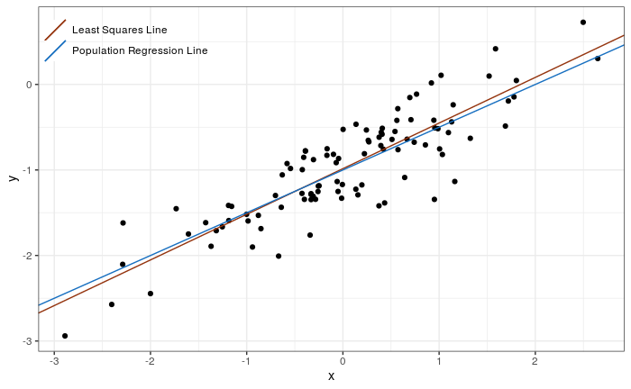

```r
data.frame(x, y) %>%
  ggplot(aes(x, y)) +
  geom_point(color = "black") +
  geom_abline(aes(intercept = coef(mod3)[1], slope = coef(mod3)[2], # least squares line
              color = "Least Squares Line")) +
  geom_abline(aes(intercept = -1, slope = 0.5, # population regression line
              color = "Population Regression Line")) +
  scale_colour_manual(name = NULL,
                      values = c("Least Squares Line" = ISLR_brown,
                                 "Population Regression Line" = ISLR_blue)) +
  theme(legend.position = c(0, 1),
        legend.justification = c(0, 1),
        legend.background = element_blank())
```

### (i)

```r
x <- rnorm(100, mean = 0, sd = 1)
eps <- rnorm(100, mean = 0, sd = sqrt(0.5))
y <- -1 + 0.5*x + eps
```

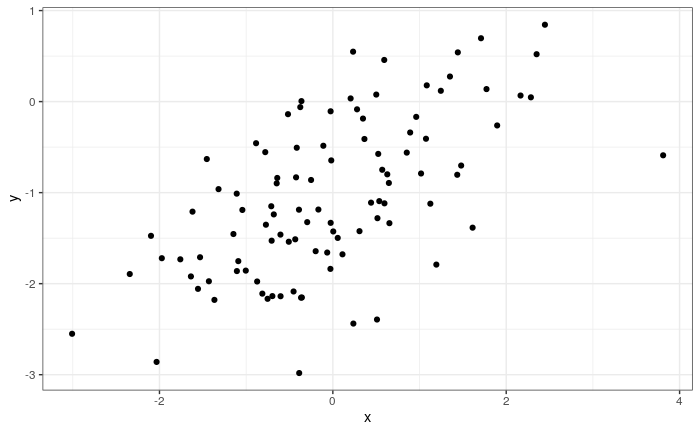

```r
data.frame(x, y) %>%
  ggplot(aes(x, y)) +
  geom_point(color = "black")
```

There is now a less clear linear relationship between `x` and `y`.

```r
mod4 <- lm(y ~ x)
summary(mod4)
```

```
Call:
lm(formula = y ~ x)

Residuals:
    Min      1Q  Median      3Q     Max
-1.7749 -0.4281  0.0146  0.4984  1.4777

Coefficients:
            Estimate Std. Error t value Pr(>|t|)
(Intercept) -1.03355    0.06842 -15.105  < 2e-16 ***
x            0.44700    0.05876   7.607 1.73e-11 ***
---
Signif. codes:  0 ‘***’ 0.001 ‘**’ 0.01 ‘*’ 0.05 ‘.’ 0.1 ‘ ’ 1

Residual standard error: 0.6838 on 98 degrees of freedom
Multiple R-squared:  0.3713,    Adjusted R-squared:  0.3648
F-statistic: 57.87 on 1 and 98 DF,  p-value: 1.731e-11
```

The estimate for the intercept ($\hat{\beta_0} = -1.03355$) and slope ($\hat{\beta_1} = 0.44700$) are close to the true values in (c). They are less accurate than the models where less noise was present.

Plot the two regression lines:

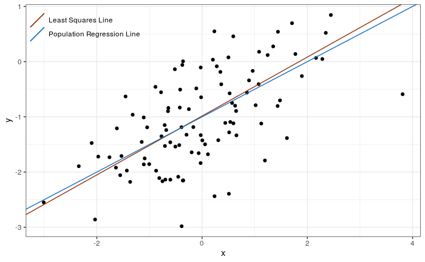

```r
data.frame(x, y) %>%
  ggplot(aes(x, y)) +
  geom_point(color = "black") +
  geom_abline(aes(intercept = coef(mod3)[1], slope = coef(mod3)[2], # least squares line
              color = "Least Squares Line")) +
  geom_abline(aes(intercept = -1, slope = 0.5, # population regression line
              color = "Population Regression Line")) +
  scale_colour_manual(name = NULL,
                      values = c("Least Squares Line" = ISLR_brown,
                                 "Population Regression Line" = ISLR_blue)) +
  theme(legend.position = c(0, 1),
        legend.justification = c(0, 1),
        legend.background = element_blank())
```

### (j)

The confidence intervals are shorter for the model with less noise (`mod3`) and wider for the model with more noise (`mod4`). The first model (`mod1`) is in between the two. In all three cases the confidence interval contains the true values for the population parameters $\beta_0$ and $\beta_1$:

```r
cbind(confint(mod1), "width" = abs(confint(mod1)[ , 1] - confint(mod1)[ , 2]))
```

```
                 2.5 %     97.5 %     width
(Intercept) -1.1150804 -0.9226122 0.1924681
x            0.3925794  0.6063602 0.2137808
```

```r
cbind(confint(mod3), "width" = abs(confint(mod3)[ , 1] - confint(mod3)[ , 2]))
```

```
                 2.5 %     97.5 %     width
(Intercept) -1.0468683 -0.9224893 0.1243790
x            0.4731823  0.5939962 0.1208139
```

```r
cbind(confint(mod4), "width" = abs(confint(mod4)[ , 1] - confint(mod4)[ , 2]))
```

```
                 2.5 %     97.5 %     width
(Intercept) -1.1693360 -0.8977719 0.2715640
x            0.3303927  0.5636136 0.2332208
```

## Exercise 14

### (a)

Generate data:

```r
set.seed(1)
x1 <- runif(100)
x2 <- 0.5*x1 + rnorm(100)/10
y <- 2 + 2*x1 + 0.3*x2 + rnorm(100)
```

Model form:
$$Y=\beta_{0}+\beta_{1}X_{1}+\beta_{2}X_{2}+\epsilon=2+2X_{1}+0.3X_{2}+\epsilon$$
Regression coefficients:

- $\beta_{0}=2$
- $\beta_{1}=2$
- $\beta_{2}=0.3$

### (b)

Correlation:

```r
cor(x1, x2)
```

```
[1] 0.8351212
```

Scatterplot:

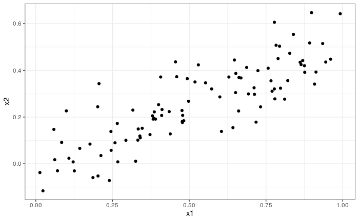

```r
data.frame(x1, x2) %>%
  ggplot(aes(x1, x2)) +
  geom_point()
```

### (c)

```r
mod1 <- lm(y ~ x1 + x2)
summary(mod1)
```

```
Call:
lm(formula = y ~ x1 + x2)

Residuals:
    Min      1Q  Median      3Q     Max
-2.8311 -0.7273 -0.0537  0.6338  2.3359

Coefficients:
            Estimate Std. Error t value Pr(>|t|)
(Intercept)   2.1305     0.2319   9.188 7.61e-15 ***
x1            1.4396     0.7212   1.996   0.0487 *
x2            1.0097     1.1337   0.891   0.3754
---
Signif. codes:  0 ‘***’ 0.001 ‘**’ 0.01 ‘*’ 0.05 ‘.’ 0.1 ‘ ’ 1

Residual standard error: 1.056 on 97 degrees of freedom
Multiple R-squared:  0.2088,    Adjusted R-squared:  0.1925
F-statistic:  12.8 on 2 and 97 DF,  p-value: 1.164e-05
```

The model has a low R-squared of 0.2088 indicating that it only accounts for ~21% of the variability in the data.

Coefficients:

- $\hat{\beta}_{0}=2.1305$, close to real value of $\beta_{0}=2$
- $\hat{\beta}_{1}=1.4396$, not close to real value of $\beta_{1}=2$
- $\hat{\beta}_{2}=1.0097$, not close to real value of $\beta_{2}=0.3$

The null hypothesis $H_{0}:\beta_{1}=0$ can be rejected at the $\alpha=0.05$ level. The null hypothesis $H_{0}:\beta_{2}=0$ can not be rejected as the p-value is too high.

### (d)

```r
mod2 <- lm(y ~ x1)
summary(mod2)
```

```
Call:
lm(formula = y ~ x1)

Residuals:
     Min       1Q   Median       3Q      Max
-2.89495 -0.66874 -0.07785  0.59221  2.45560

Coefficients:
            Estimate Std. Error t value Pr(>|t|)
(Intercept)   2.1124     0.2307   9.155 8.27e-15 ***
x1            1.9759     0.3963   4.986 2.66e-06 ***
---
Signif. codes:  0 ‘***’ 0.001 ‘**’ 0.01 ‘*’ 0.05 ‘.’ 0.1 ‘ ’ 1

Residual standard error: 1.055 on 98 degrees of freedom
Multiple R-squared:  0.2024,    Adjusted R-squared:  0.1942
F-statistic: 24.86 on 1 and 98 DF,  p-value: 2.661e-06
```

$\hat{\beta}_{1}$, the coefficient for `x1`, is statistically significant as the p-value is very low. Hence, we can reject the null hypothesis $H_{0}:\beta_{1}=0$. The model still has a low R-squared value of 0.2024.

### (e)

```r
mod3 <- lm(y ~ x2)
summary(mod3)
```

```
Call:
lm(formula = y ~ x2)

Residuals:
     Min       1Q   Median       3Q      Max
-2.62687 -0.75156 -0.03598  0.72383  2.44890

Coefficients:
            Estimate Std. Error t value Pr(>|t|)
(Intercept)   2.3899     0.1949   12.26  < 2e-16 ***
x2            2.8996     0.6330    4.58 1.37e-05 ***
---
Signif. codes:  0 ‘***’ 0.001 ‘**’ 0.01 ‘*’ 0.05 ‘.’ 0.1 ‘ ’ 1

Residual standard error: 1.072 on 98 degrees of freedom
Multiple R-squared:  0.1763,    Adjusted R-squared:  0.1679
F-statistic: 20.98 on 1 and 98 DF,  p-value: 1.366e-05
```

$\hat{\beta}_{1}$, the coefficient for `x2`, is also statistically significant as the p-value is very low. Hence, we can reject the null hypothesis $H_{0}:\beta_{1}=0$. When `x2` was included as a predictor with `x1`, `x2` did not have a statistically significant affect. However when `x2` is the only predictor it does.

The model also has a low R-squared value of 0.1763.

### (f)

The results do not contradict. Rather, they are a result of *collinearity*. We saw that `x1` and `x2` were highly correlated. Indeed, `x2` is generated linearly from `x1`. Therefore we can linearly predict `x1` from `x2` (and vice-versa) with a substantial degree of accuracy. When both variables are combined in the same linear model, one of them loses explanatory power because the variance it explains is already being explained by the other variable. Accordingly, if considered individually, both variables lead to the rejection of the null hypothesis. But if considered together, one of the variables is no longer significant.

*Adapted from ISLR (pg 99):*  
*Collinearity* refers to the situation in which two or more predictor variables are closely related to one another. The predictors `x1` and `x2`are highly correlated with each other, and we say that they are *collinear*. The presence of collinearity can pose problems in the regression context, since it can be difficult to separate out the individual effects of collinear variables on the response. In other words, since `x1` and `x2` tend to increase or decrease together, it can be difficult to determine how each one separately is associated with the response, `y`.  
[In calculating the coefficient values that yield the smallest RSS—that is, the least squares estimates—a small change in the data could cause the coefficient values to move anywhere along a large range.] This results in a great deal of uncertainty in the coefficient estimates.  
Since collinearity reduces the accuracy of the estimates of the regression coefficients, it causes the standard error for $\beta_{j}$ to grow. Recall that the t-statistic for each predictor is calculated by dividing $\beta_{j}$ by its standard error. Consequently, collinearity results in a decline in the t-statistic. As a result, in the presence of collinearity, we may fail to reject $H_{0}:\beta_{j}=0$. This means that the power of the hypothesis test—the probability of correctly detecting a non-zero coefficient—is reduced by collinearity.  
A simple way to detect collinearity is to look at the correlation matrix of the predictors. An element of this matrix that is large in absolute value indicates a pair of highly correlated variables, and therefore a collinearity problem in the data. Unfortunately, not all collinearity problems can be detected by inspection of the correlation matrix: it is possible for collinearity to exist between three or more variables even if no pair of variables has a particularly high correlation. We call this situation *multicollinearity*. Instead of inspecting the correlation matrix, a better way to assess multi-collinearity is to compute the *variance inflation factor* (VIF).

### (g)

Add the new (incorrectly measured) point to the data:

```r
x1 <- c(x1, 0.1)
x2 <- c(x2, 0.8)
y <- c(y, 6)
```

Before making the models, plot the data and inspect for outliers and high leverage points (the new data point is in red):

`(x1, x2)`:

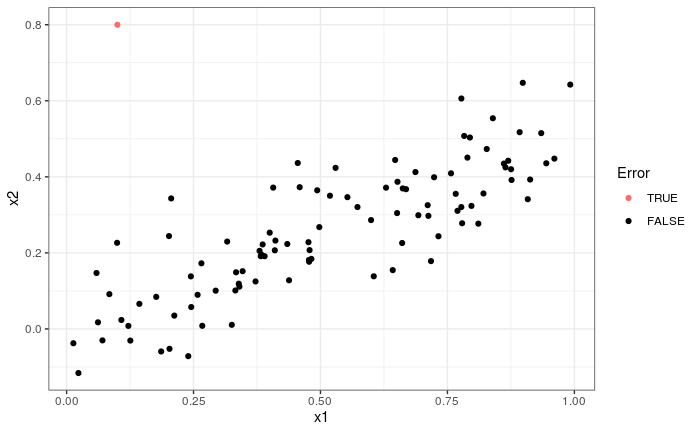

```r
tibble(x1, x2) %>%
  mutate(flag = row_number() == n()) %>%
  ggplot(aes(x1, x2)) +
  geom_point(aes(color = flag)) +
  scale_color_manual(name = "Error",
                     breaks = c(TRUE, FALSE),
                     values = c("indianred1", "black"))
```

There is an unusual combination of predictor values, so it looks like a high leverage point. We cannot decide if this point is an outlier as we have not included `y` on the plot.

`(x1, y)`:

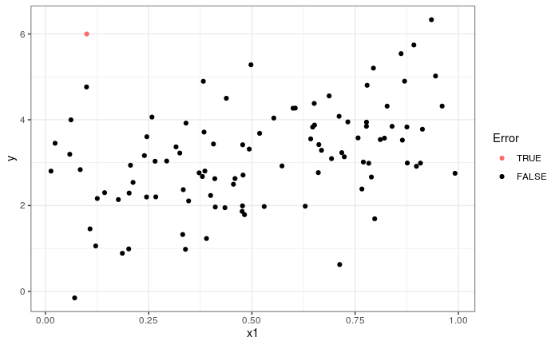

```r
tibble(x1, y) %>%
  mutate(flag = row_number() == n()) %>%
  ggplot(aes(x1, y)) +
  geom_point(aes(color = flag)) +
  scale_color_manual(name = "Error",
                     breaks = c(TRUE, FALSE),
                     values = c("indianred1", "black"))
```

The red point doesn’t follow the trend so it may be an outlier. The red point doesn’t have an unusual `x1` value, so it doesn’t look like a high leverage point.

`(x2, y)`:

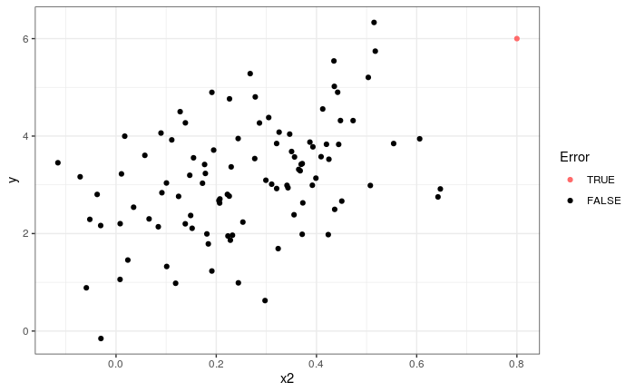

```r
tibble(x2, y) %>%
  mutate(flag = row_number() == n()) %>%
  ggplot(aes(x2, y)) +
  geom_point(aes(color = flag)) +
  scale_color_manual(name = "Error",
                     breaks = c(TRUE, FALSE),
                     values = c("indianred1", "black"))
```

The red point follows the trend, so it doesn’t look like an outlier. The red point has the largest `x2` value, so it might be a high leverage point.

Now update the models with the new data and see how it affect the coefficients. We can then inspect the model plots to see if the point is an outlier or a high leverage point.

**Model (c) (`lm(y ~ x1 + x2)`)**

```r
mod1.2 <- lm(y ~ x1 + x2)
summary(mod1.2)
```

```
Call:
lm(formula = y ~ x1 + x2)

Residuals:
     Min       1Q   Median       3Q      Max
-2.73348 -0.69318 -0.05263  0.66385  2.30619

Coefficients:
            Estimate Std. Error t value Pr(>|t|)
(Intercept)   2.2267     0.2314   9.624 7.91e-16 ***
x1            0.5394     0.5922   0.911  0.36458
x2            2.5146     0.8977   2.801  0.00614 **
---
Signif. codes:  0 ‘***’ 0.001 ‘**’ 0.01 ‘*’ 0.05 ‘.’ 0.1 ‘ ’ 1

Residual standard error: 1.075 on 98 degrees of freedom
Multiple R-squared:  0.2188,    Adjusted R-squared:  0.2029
F-statistic: 13.72 on 2 and 98 DF,  p-value: 5.564e-06
```

A small change in the data has caused a substantial difference in the model. Previously, `x1` was significant and `x2` was not. Now the opposite is true.

The R-squared value of the second model (0.2188) is slightly higher than the first model (0.2088).

Below is a table of the coefficients from each model:

```r
rbind(c("Original data", "", "", ""), round(coef(summary(mod1)), 2), c("Updated data", "", "", ""), round(coef(summary(mod1.2)), 2))
```

```
            Estimate        Std. Error t value Pr(>|t|)
            "Original data" ""         ""      ""
(Intercept) "2.13"          "0.23"     "9.19"  "0"
x1          "1.44"          "0.72"     "2"     "0.05"
x2          "1.01"          "1.13"     "0.89"  "0.38"
            "Updated data"  ""         ""      ""
(Intercept) "2.23"          "0.23"     "9.62"  "0"
x1          "0.54"          "0.59"     "0.91"  "0.36"
x2          "2.51"          "0.9"      "2.8"   "0.01"
```

Inspect the residual and leverage plots of the new model:

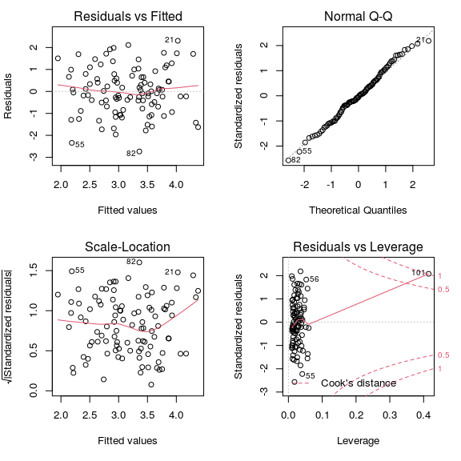

```r
par(mfrow = c(2, 2))
plot(mod1.2)
```

The new data point (numbered 101) doesn’t appear to be an outlier. However we can see that it does have high leverage (as we suspected from the above plot of `x1` vs `x2`). This is to be expected as it had a significant effect on the coefficients of the model.

**Model (d) (`lm(y ~ x1)`)**

```r
mod2.2 <- lm(y ~ x1)
summary(mod2.2)
```

```
Call:
lm(formula = y ~ x1)

Residuals:
    Min      1Q  Median      3Q     Max
-2.8897 -0.6556 -0.0909  0.5682  3.5665

Coefficients:
            Estimate Std. Error t value Pr(>|t|)
(Intercept)   2.2569     0.2390   9.445 1.78e-15 ***
x1            1.7657     0.4124   4.282 4.29e-05 ***
---
Signif. codes:  0 ‘***’ 0.001 ‘**’ 0.01 ‘*’ 0.05 ‘.’ 0.1 ‘ ’ 1

Residual standard error: 1.111 on 99 degrees of freedom
Multiple R-squared:  0.1562,    Adjusted R-squared:  0.1477
F-statistic: 18.33 on 1 and 99 DF,  p-value: 4.295e-05
```

While the coefficients have changed value, the differences are not as great as before. `x1` was significant in the first model and is still significant in this model.

The R-squared value of the second model (0.1562) is worse than the first model (0.2024).

Below is a table of the coefficients from each model:

```r
rbind(c("Original data", "", "", ""), round(coef(summary(mod2)), 2), c("Updated data", "", "", ""), round(coef(summary(mod2.2)), 2))
```

```
            Estimate        Std. Error t value Pr(>|t|)
            "Original data" ""         ""      ""
(Intercept) "2.11"          "0.23"     "9.15"  "0"
x1          "1.98"          "0.4"      "4.99"  "0"
            "Updated data"  ""         ""      ""
(Intercept) "2.26"          "0.24"     "9.44"  "0"
x1          "1.77"          "0.41"     "4.28"  "0"
```

Inspect the residual and leverage plots of the new model:

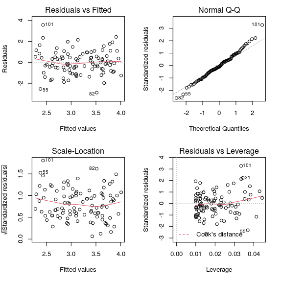

```r
par(mfrow = c(2, 2))
plot(mod2.2)
```

The new data point (numbered 101) appears to be an outlier (as we suspected from the above plot of `x1` vs `y`). However it has a normal leverage (also seen in the above plot of `x1` vs `y`). This is to be expected as it did not have a significant effect on the coefficients of the model.

**Model (e) (`lm(y ~ x2)`)**

```r
mod3.2 <- lm(y ~ x2)
summary(mod3.2)
```

```
Call:
lm(formula = y ~ x2)

Residuals:
     Min       1Q   Median       3Q      Max
-2.64729 -0.71021 -0.06899  0.72699  2.38074

Coefficients:
            Estimate Std. Error t value Pr(>|t|)
(Intercept)   2.3451     0.1912  12.264  < 2e-16 ***
x2            3.1190     0.6040   5.164 1.25e-06 ***
---
Signif. codes:  0 ‘***’ 0.001 ‘**’ 0.01 ‘*’ 0.05 ‘.’ 0.1 ‘ ’ 1

Residual standard error: 1.074 on 99 degrees of freedom
Multiple R-squared:  0.2122,    Adjusted R-squared:  0.2042
F-statistic: 26.66 on 1 and 99 DF,  p-value: 1.253e-06
```

While the coefficients have changed value, the differences are not as great as before. `x2` was significant in the first model and is still significant in this model.

The R-squared value of the second model (0.2122) is higher than the first model (0.1763).

Below is a table of the coefficients from each model:

```r
rbind(c("Original data", "", "", ""), round(coef(summary(mod3)), 2), c("Updated data", "", "", ""), round(coef(summary(mod3.2)), 2))
```

```
            Estimate        Std. Error t value Pr(>|t|)
            "Original data" ""         ""      ""
(Intercept) "2.39"          "0.19"     "12.26" "0"
x2          "2.9"           "0.63"     "4.58"  "0"
            "Updated data"  ""         ""      ""
(Intercept) "2.35"          "0.19"     "12.26" "0"
x2          "3.12"          "0.6"      "5.16"  "0"
```

Inspect the residual and leverage plots of the new model:

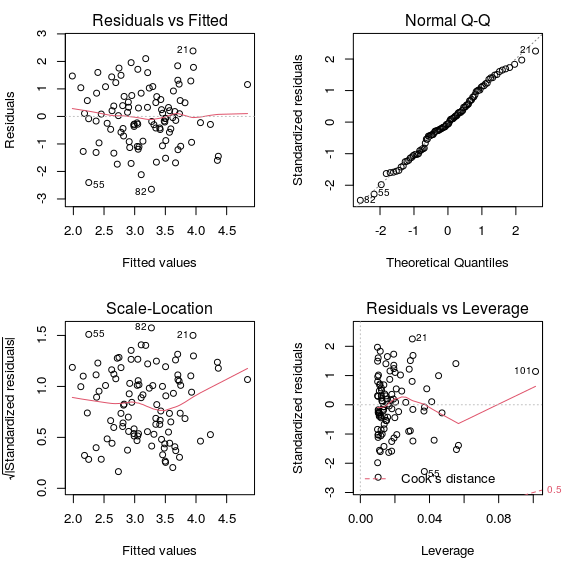

```r
par(mfrow = c(2, 2))
plot(mod3.2)
```

The new data point (numbered 101) doesn’t appear to be an outlier (as we suspected from the above plot of `x2` vs `y`). It is the point with highest leverage, however it is not significantly higher than the others (as in the first case). This is to be expected as it did not have a significant effect on the coefficients of the model.

## Exercise 15

View the `Boston` data:

```r
Boston
```

|  | crim | zn | indus | chas | nox | rm | age | dis | rad | tax | ptratio | black | lstat | medv |
| --- | --- | --- | --- | --- | --- | --- | --- | --- | --- | --- | --- | --- | --- | --- |
| 1 | 0.00632 | 18.0 | 2.31 | 0 | 0.5380 | 6.575 | 65.2 | 4.0900 | 1 | 296 | 15.3 | 396.90 | 4.98 | 24.0 |
| 2 | 0.02731 | 0.0 | 7.07 | 0 | 0.4690 | 6.421 | 78.9 | 4.9671 | 2 | 242 | 17.8 | 396.90 | 9.14 | 21.6 |
| 3 | 0.02729 | 0.0 | 7.07 | 0 | 0.4690 | 7.185 | 61.1 | 4.9671 | 2 | 242 | 17.8 | 392.83 | 4.03 | 34.7 |
| 4 | 0.03237 | 0.0 | 2.18 | 0 | 0.4580 | 6.998 | 45.8 | 6.0622 | 3 | 222 | 18.7 | 394.63 | 2.94 | 33.4 |
| 5 | 0.06905 | 0.0 | 2.18 | 0 | 0.4580 | 7.147 | 54.2 | 6.0622 | 3 | 222 | 18.7 | 396.90 | 5.33 | 36.2 |
| 6 | 0.02985 | 0.0 | 2.18 | 0 | 0.4580 | 6.430 | 58.7 | 6.0622 | 3 | 222 | 18.7 | 394.12 | 5.21 | 28.7 |
| 7 | 0.08829 | 12.5 | 7.87 | 0 | 0.5240 | 6.012 | 66.6 | 5.5605 | 5 | 311 | 15.2 | 395.60 | 12.43 | 22.9 |
| 8 | 0.14455 | 12.5 | 7.87 | 0 | 0.5240 | 6.172 | 96.1 | 5.9505 | 5 | 311 | 15.2 | 396.90 | 19.15 | 27.1 |
| 9 | 0.21124 | 12.5 | 7.87 | 0 | 0.5240 | 5.631 | 100.0 | 6.0821 | 5 | 311 | 15.2 | 386.63 | 29.93 | 16.5 |
| 10 | 0.17004 | 12.5 | 7.87 | 0 | 0.5240 | 6.004 | 85.9 | 6.5921 | 5 | 311 | 15.2 | 386.71 | 17.10 | 18.9 |

[output cut: 496 more lines]

### (a)

Create a simple linear model for each predictor:

```r
mods <- Boston %>%
  dplyr::select(-crim) %>%
  map(function(var) summary(lm(crim ~ var, data = Boston)))
```

View p-values:

```r
p.values <- map_dbl(mods, ~.$coefficients[2, 4])
data.frame(p.value = p.values)
```

|  | p.value |
| --- | --- |
| zn | 5.506472e-06 |
| indus | 1.450349e-21 |
| chas | 2.094345e-01 |
| nox | 3.751739e-23 |
| rm | 6.346703e-07 |
| age | 2.854869e-16 |
| dis | 8.519949e-19 |
| rad | 2.693844e-56 |
| tax | 2.357127e-47 |
| ptratio | 2.942922e-11 |

[output cut: 3 more lines]

The p-value for the single predictor’s coefficient is significant in all cases except `chas`:

```r
p.values[p.values > 0.05]
```

```
     chas
0.2094345
```

Plot each predictor versus the response `crim` along with the least squares regression line:

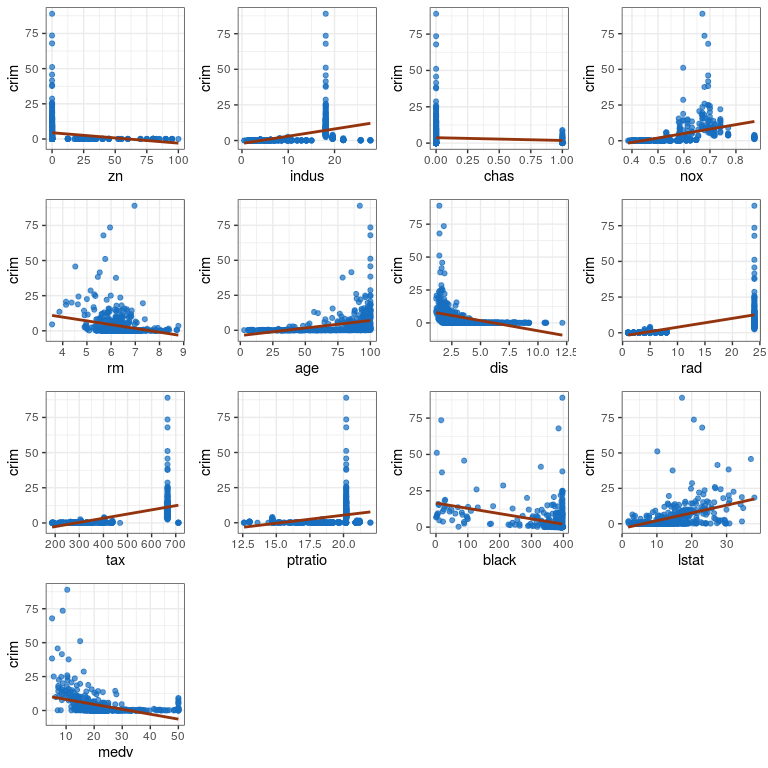

```r
G <- Boston %>%
  dplyr::select(-crim) %>%
  names() %>%
  map(function(var) {
    g <- ggplot(data = Boston, aes(x = .data[[var]], y = crim)) +
      geom_point(color = ISLR_blue, alpha = 0.7) +
      geom_smooth(method = "lm", se = FALSE,
                  color = ISLR_brown)
    return(g)
  })

cowplot::plot_grid(plotlist = G, nrow = 4)
```

The linear correlation of `crim` with each variable is only close to zero for `chas`:

```r
cor(Boston)[ , 1]
```

```
       crim          zn       indus        chas         nox          rm         age         dis         rad         tax     ptratio
 1.00000000 -0.20046922  0.40658341 -0.05589158  0.42097171 -0.21924670  0.35273425 -0.37967009  0.62550515  0.58276431  0.28994558
      black       lstat        medv
-0.38506394  0.45562148 -0.38830461
```

### (b)

Create a multiple linear regression model with all predictors:

```r
mod2 <- lm(crim ~ ., data = Boston)
summary(mod2)
```

```
Call:
lm(formula = crim ~ ., data = Boston)

Residuals:
   Min     1Q Median     3Q    Max
-9.924 -2.120 -0.353  1.019 75.051

Coefficients:
              Estimate Std. Error t value Pr(>|t|)
(Intercept)  17.033228   7.234903   2.354 0.018949 *
zn            0.044855   0.018734   2.394 0.017025 *
indus        -0.063855   0.083407  -0.766 0.444294
chas         -0.749134   1.180147  -0.635 0.525867
nox         -10.313535   5.275536  -1.955 0.051152 .
rm            0.430131   0.612830   0.702 0.483089
age           0.001452   0.017925   0.081 0.935488
dis          -0.987176   0.281817  -3.503 0.000502 ***
rad           0.588209   0.088049   6.680 6.46e-11 ***
tax          -0.003780   0.005156  -0.733 0.463793
ptratio      -0.271081   0.186450  -1.454 0.146611
black        -0.007538   0.003673  -2.052 0.040702 *
lstat         0.126211   0.075725   1.667 0.096208 .
medv         -0.198887   0.060516  -3.287 0.001087 **
---
Signif. codes:  0 ‘***’ 0.001 ‘**’ 0.01 ‘*’ 0.05 ‘.’ 0.1 ‘ ’ 1

Residual standard error: 6.439 on 492 degrees of freedom
Multiple R-squared:  0.454, Adjusted R-squared:  0.4396
F-statistic: 31.47 on 13 and 492 DF,  p-value: < 2.2e-16
```

We can reject the null hypothesis $H_{0}:\beta_{j}=0$ for predictors `dis`, `rad` and `medv` at the **1% level**. The predictors `zn` and `black` are also significant at the **5% level**. The other predictors are not found to have a statistically significant association with the response.